PART 2

# Language Models and Agents for Statistical Programming

Jimeng Sun · Yilong Zhang

Boston Pharmaceutical Statistics Symposium · Nov 12, 2026

## Part 2 at a glance

|  | Topic | Time |
| --- | --- | --- |
| 1 | **The expert’s new job** | 11 min |
| 2 | **Agents built to be checked** | 17 min |
| 3 | **Seven strategies beyond skills and tools** | 20 min |
| 4 | **Verify before you deploy** | 7 min |

Disclosure: Jimeng Sun is co-founder and CEO of Keiji AI, which builds TrialMind, the platform used in the demos.

# The expert’s new job

Generating is cheap. Verifying is not.

## 722 manuscripts in one day

722

math manuscripts from one AI model

42%

checkable by computer (Lean)

3

withdrawn the next day, for one sign error

Generating results is cheap. **Verifying them is not.**

OpenAI mathematics releases, Oct 2026 · Retraction Watch, 8 Oct 2026

## AI is moving the frontier in life science

[figure not shown]

The opportunity is real. **What should experts do?**

AlphaFold Protein Structure Database (2022); Nobel Prize in Chemistry (2024) · Xu Z, et al. Rentosertib in idiopathic pulmonary fibrosis: a randomized phase 2a trial. *Nat Med* (2025) · FDA draft guidance on AI for regulatory decision-making (Jan 2025); FDA launch of Elsa (Jun 2025)

## Six roles for the expert

[figure not shown]

The job moves from **generating** to **certifying**.

## 1. Questioner

[figure not shown]

Works while you know more. Fails when **wrong answers look right**.

## 2. Learner

[figure not shown]

The test of understanding: **can you derive it by hand?**

## 3. Verifier

[figure not shown]

Double programming, with an agent as **one of the programmers**.

## 4. Manager

[figure not shown]

You can delegate the work. **You cannot delegate the responsibility.**

## 5. Editor

[figure not shown]

Hundreds of tables become **the one paragraph a regulator reads**.

## 6. Owner

[figure not shown]

The signature stays **with a person**.

## The verifier steers the frontier

[figure not shown]

Whoever builds the verifier **shapes the field**.

## Statisticians already have a verifier

[figure not shown]

Same protocol, one box changed: **people review the disagreements**.

# Agents built to be checked

Three agents, each built so a reviewer can check its work.

## Three agents, three ways to check

| Agent | How a reviewer checks it |
| --- | --- |
| **Literature review** | Every number links to its source passage |
| **TrialPanorama** | Every row cites its registry record |
| **Statistical programming** | An independent QC program and a comparison decide |

Wang Z, et al. *npj Digit Med* 8, 509 (2025) · Wang Z, et al. *Nat Commun* 16, 947 (2025) · Wang Z, et al. *Nat Biomed Eng* (2025)

## Demo 1: systematic literature review

[figure not shown]

The reviewer no longer redoes the review. **They audit the leaves.**

## Demo 2: TrialPanorama

[figure not shown]

An answer you can check in minutes: **the query, the counts, and the record.**

## Demo 3: statistical programming agent

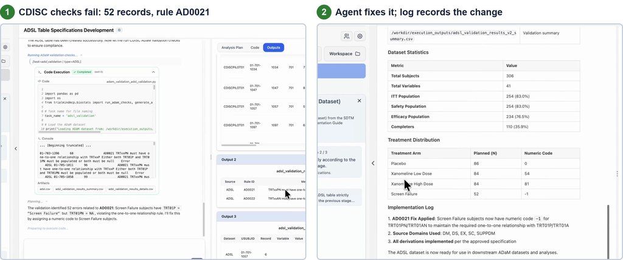

The checks, not the model, **decide what is correct.**

# Seven strategies beyond skills and tools

What makes an agent better, and its work easier to check.

## Where can an agent be improved?

[figure not shown]

Beyond skills and tools: **seven strategies, by what they change.**

## Complete the specification

[figure not shown]

Same 134 tasks, same agent (Part 1)

Python pass rate by prompt tier

Full133 / 134

Conventions48 / 134

Brief25 / 134

5.3x

more tasks passed with the rules written down

What to do

- **Write the rules down** before tuning anything else.
- What is left out is filled by a language default or by memory of a public program.
- **Reward asking:** a flagged ambiguity is a question for the statistician, not a silent choice.

## Engineer the context

[figure not shown]

> The model knows only its context. What the harness puts there is a design decision.

## Restructure the output

[figure not shown]

> Ask for what tested code can execute. With yamaa, every error became a **refusal with named issues**, never a wrong dataset.

## Adapt the model

[figure not shown]

Design first, choose where it runs, **fine-tune last.**

## Feed back checkable signals

[figure not shown]

Every agent loops. What matters is **what comes back.**

## Put the SOP in code

[figure not shown]

Don’t ask the agent to follow the SOP. **Make the SOP run the agent.**

## When the data talk to the agent

[figure not shown]

Make a successful injection **harmless**; don’t rely on the model to resist it.

## Check independently

[figure not shown]

> A review that never changes anything is not a control. Track how often reviewers return agent output.

## Where AI fits in a validated environment

[figure not shown]

Validation follows one question: **does a person fully check the AI’s output?**

FDA draft guidance on AI for regulatory decision-making (Jan 2025) · EU GMP draft Annex 22 · ICH E6(R3) · 21 CFR Part 11

## Seven strategies, in one slide

[figure not shown]

Each strategy makes the agent better **and its work easier to check.**

# Verify before you deploy

How to check any AI tool, and how checking itself fails.

## Five questions for any AI tool

[figure not shown]

Ask every vendor, **including us**, and your own team.

## Verification has its own failure modes

82% vs 46%

radiologists correct when AI advice was right vs wrong

28% → 22%

adenoma detection without AI, after routine AI use

FAA, 2013: fly by hand more often, **because autopilot is so good**.

Dratsch T, et al. *Radiology* (2023) · Budzyń K, et al. *Lancet Gastroenterol Hepatol* (2025) · FAA SAFO 13002 (2013)

## Five first steps

1. **Pick one piece of work you check**, and write down the rule an AI would miss.
2. **Write one set of rules down** so they can be checked.
3. **Test one AI output** against a check you already trust.
4. **Ask every AI vendor** where answers come from and what checks them.
5. **Keep sign-off with a person.**

“What I cannot create, I do not understand.”  
Richard Feynman

**What I cannot verify, I should not deploy.**

## References

- **Companion tutorial:** Part III (Sections 8–15) for the seven strategies and case studies.
- **Course slides:** https://ai4csr.org/slides/asa-boston-2026-11-12/
- **The 722 manuscripts:** Retraction Watch, 8 Oct 2026; *Nature* news, Oct 2026.
- **Verifiable rewards:** Guo D, et al. DeepSeek-R1. *Nature* 645:633–638 (2025) · Arora RK, et al. HealthBench. OpenAI (2025).
- **Reproducibility:** Buckheit JB, Donoho DL. WaveLab and reproducible research (1995) · Begley CG, Ellis LM. *Nature* 483:531–533 (2012).
- **Expert roles:** Sadler M, Regan N. *Game Changer* (2019).

## Questions

Thank you. Part 3 next: designing the evaluation of an AI agent as a study.